# ITP-Shopify Store - Assignment 4 - Collections and Navigation

Author

Juan De La Cruz-Calderon

Published

July 16, 2026

# 1 Introduction

Juanito’s Card Vault is a Shopify prototype store designed for Pokémon Trading Card Game enthusiasts. The purpose of this assignment was to organize products into logical collections and improve the store’s navigation so customers can browse products more efficiently. Effective collections and navigation are essential in e-commerce because they improve product discovery, reduce customer frustration, and create a better overall shopping experience.

# 2 Collections and Categories

To improve product organization, I created the following collections within my Shopify store:

- Booster Packs
- Elite Trainer Boxes (ETBs)
- Single Cards
- Accessories

Each collection groups together similar products, making it easier for customers to browse items based on what they are looking for instead of searching through the entire catalog.

**Store Organization**

Organizing products into collections helps create a more user-friendly shopping experience by allowing customers to browse related products in one place.

# 3 Navigation Menu

> A clear navigation menu is one of the most important features of an online store because it allows customers to quickly locate products and explore different categories.

# 4 Screenshots

## 4.1 Shopify Admin Collections

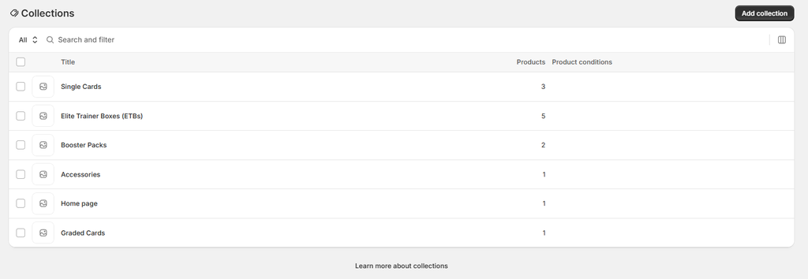

## 4.2 Collection Pages

[figure not shown]